# delay_cause_exploratory_analysis

## AirLines Delay Causes Exploration

## By Hosam Elbakry

> The data we have here -from Udacity datasets options- is airlines delay causes from 2017 till 2020 and contains 22 column and 69522 record or row through the project we will start to understand the dataset variables and carryout the necessary wrangling/cleaning and then figure out which variables worthy to be concluded in our analysis. The insights we are trying to inspect here for example what is the main cause of delay, what is the best time for travel, is the destination affect on delay.

```python
# import libriaries #
import numpy as np
import matplotlib.pyplot as plt
import pandas as pd
import seaborn as sns
```

```python
# Read the dataset #
df = pd.read_csv('Airline_delay_causes17_20.csv')
df.info()
```

```
<class 'pandas.core.frame.DataFrame'>
RangeIndex: 69522 entries, 0 to 69521
Data columns (total 22 columns):
 #   Column               Non-Null Count  Dtype
---  ------               --------------  -----
 0   year                 69522 non-null  int64
 1    month               69522 non-null  int64
 2   carrier              69522 non-null  object
 3   carrier_name         69522 non-null  object
 4   airport              69522 non-null  object
 5   airport_name         69522 non-null  object
 6   arr_flights          69409 non-null  float64
 7   arr_del15            69227 non-null  float64
 8   carrier_ct           69409 non-null  float64
 9    weather_ct          69409 non-null  float64
 10  nas_ct               69409 non-null  float64
 11  security_ct          69409 non-null  float64
 12  late_aircraft_ct     69409 non-null  float64
 13  arr_cancelled        69409 non-null  float64
 14  arr_diverted         69409 non-null  float64
 15   arr_delay           69409 non-null  float64
 16   carrier_delay       69409 non-null  float64
 17  weather_delay        69409 non-null  float64
 18  nas_delay            69409 non-null  float64
 19  security_delay       69409 non-null  float64
 20  late_aircraft_delay  69409 non-null  float64
 21  Unnamed: 21          0 non-null      float64
dtypes: float64(16), int64(2), object(4)
memory usage: 11.7+ MB
```

```python
df.head()
```

|  | year | month | carrier | carrier_name | airport | airport_name | arr_flights | arr_del15 | carrier_ct | weather_ct | ... | late_aircraft_ct | arr_cancelled | arr_diverted | arr_delay | carrier_delay | weather_delay | nas_delay | security_delay | late_aircraft_delay | Unnamed: 21 |
| --- | --- | --- | --- | --- | --- | --- | --- | --- | --- | --- | --- | --- | --- | --- | --- | --- | --- | --- | --- | --- | --- |
| 0 | 2017 | 1 | AA | American Airlines Inc. | ABQ | Albuquerque, NM: Albuquerque International Sun... | 125.0 | 31.0 | 16.26 | 1.00 | ... | 10.36 | 1.0 | 0.0 | 1378.0 | 758.0 | 21.0 | 95.0 | 0.0 | 504.0 | NaN |
| 1 | 2017 | 1 | AA | American Airlines Inc. | ALB | Albany, NY: Albany International | 88.0 | 10.0 | 4.52 | 0.00 | ... | 4.41 | 1.0 | 0.0 | 402.0 | 171.0 | 0.0 | 17.0 | 0.0 | 214.0 | NaN |
| 2 | 2017 | 1 | AA | American Airlines Inc. | AMA | Amarillo, TX: Rick Husband Amarillo International | 24.0 | 6.0 | 1.65 | 0.30 | ... | 2.79 | 1.0 | 0.0 | 419.0 | 59.0 | 64.0 | 166.0 | 0.0 | 130.0 | NaN |
| 3 | 2017 | 1 | AA | American Airlines Inc. | ATL | Atlanta, GA: Hartsfield-Jackson Atlanta Intern... | 1112.0 | 204.0 | 72.58 | 2.34 | ... | 65.02 | 24.0 | 6.0 | 11968.0 | 4237.0 | 108.0 | 2693.0 | 159.0 | 4771.0 | NaN |
| 4 | 2017 | 1 | AA | American Airlines Inc. | AUS | Austin, TX: Austin - Bergstrom International | 729.0 | 126.0 | 47.75 | 2.86 | ... | 38.06 | 2.0 | 0.0 | 6816.0 | 3096.0 | 103.0 | 1419.0 | 110.0 | 2088.0 | NaN |

5 rows × 22 columns

```python
df.describe()
```

|  | year | month | arr_flights | arr_del15 | carrier_ct | weather_ct | nas_ct | security_ct | late_aircraft_ct | arr_cancelled | arr_diverted | arr_delay | carrier_delay | weather_delay | nas_delay | security_delay | late_aircraft_delay | Unnamed: 21 |
| --- | --- | --- | --- | --- | --- | --- | --- | --- | --- | --- | --- | --- | --- | --- | --- | --- | --- | --- |
| count | 69522.000000 | 69522.000000 | 69409.000000 | 69227.000000 | 69409.000000 | 69409.000000 | 69409.000000 | 69409.000000 | 69409.000000 | 69409.000000 | 69409.000000 | 69409.000000 | 69409.000000 | 69409.000000 | 69409.000000 | 69409.000000 | 69409.000000 | 0.0 |
| mean | 2018.576537 | 6.256653 | 349.561786 | 59.693790 | 16.923286 | 2.006346 | 19.136294 | 0.117834 | 21.353522 | 8.779193 | 0.805501 | 3919.384979 | 1232.435779 | 210.322898 | 950.610137 | 5.825945 | 1520.180092 | NaN |
| std | 1.029360 | 3.377271 | 977.441321 | 166.723838 | 41.594077 | 6.381085 | 63.660558 | 0.551568 | 64.955629 | 58.435444 | 3.474642 | 11946.559461 | 3545.390769 | 778.382090 | 3801.853245 | 36.311054 | 4745.222964 | NaN |
| min | 2017.000000 | 1.000000 | 1.000000 | 0.000000 | 0.000000 | 0.000000 | 0.000000 | 0.000000 | 0.000000 | 0.000000 | 0.000000 | 0.000000 | 0.000000 | 0.000000 | 0.000000 | 0.000000 | 0.000000 | NaN |
| 25% | 2018.000000 | 3.000000 | 44.000000 | 5.000000 | 1.840000 | 0.000000 | 1.000000 | 0.000000 | 1.000000 | 0.000000 | 0.000000 | 271.000000 | 85.000000 | 0.000000 | 32.000000 | 0.000000 | 50.000000 | NaN |
| 50% | 2019.000000 | 6.000000 | 92.000000 | 15.000000 | 5.190000 | 0.280000 | 3.630000 | 0.000000 | 4.520000 | 1.000000 | 0.000000 | 911.000000 | 317.000000 | 14.000000 | 135.000000 | 0.000000 | 294.000000 | NaN |
| 75% | 2019.000000 | 9.000000 | 236.000000 | 41.000000 | 13.840000 | 1.680000 | 10.890000 | 0.000000 | 13.920000 | 4.000000 | 1.000000 | 2625.000000 | 959.000000 | 134.000000 | 445.000000 | 0.000000 | 1002.000000 | NaN |
| max | 2020.000000 | 12.000000 | 21931.000000 | 4176.000000 | 1027.450000 | 188.680000 | 1884.420000 | 26.070000 | 1443.450000 | 4951.000000 | 143.000000 | 429194.000000 | 151581.000000 | 28294.000000 | 112018.000000 | 3194.000000 | 147167.000000 | NaN |

### Fisrt Let us choose only the columns of delay cause and some supporting factors to facilitste the data Wrangling, Cleaning process.

Note: in order to understand the terms listed in the dataset please check the below link https://www.transtats.bts.gov/OT_Delay/ot_delaycause1.asp?type=21&pn=1

```python
# df.drop(columns=['Unnamed: 21','carrier_name','airport_name'], inplace=True)
df_cause=df[['year','carrier','carrier_name',' month','airport','airport_name',' arr_delay',' carrier_delay','weather_delay','nas_delay','security_delay','late_aircraft_delay']]
```

```python
print(sum(df_cause.duplicated()))
print(sum(df_cause.count().isnull()))
print(df_cause.isna().sum())
```

```
0
0
year                     0
carrier                  0
carrier_name             0
 month                   0
airport                  0
airport_name             0
 arr_delay             113
 carrier_delay         113
weather_delay          113
nas_delay              113
security_delay         113
late_aircraft_delay    113
dtype: int64
```

```python
df_cause.describe()
```

|  | year | month | arr_delay | carrier_delay | weather_delay | nas_delay | security_delay | late_aircraft_delay |
| --- | --- | --- | --- | --- | --- | --- | --- | --- |
| count | 69522.000000 | 69522.000000 | 69409.000000 | 69409.000000 | 69409.000000 | 69409.000000 | 69409.000000 | 69409.000000 |
| mean | 2018.576537 | 6.256653 | 3919.384979 | 1232.435779 | 210.322898 | 950.610137 | 5.825945 | 1520.180092 |
| std | 1.029360 | 3.377271 | 11946.559461 | 3545.390769 | 778.382090 | 3801.853245 | 36.311054 | 4745.222964 |
| min | 2017.000000 | 1.000000 | 0.000000 | 0.000000 | 0.000000 | 0.000000 | 0.000000 | 0.000000 |
| 25% | 2018.000000 | 3.000000 | 271.000000 | 85.000000 | 0.000000 | 32.000000 | 0.000000 | 50.000000 |
| 50% | 2019.000000 | 6.000000 | 911.000000 | 317.000000 | 14.000000 | 135.000000 | 0.000000 | 294.000000 |
| 75% | 2019.000000 | 9.000000 | 2625.000000 | 959.000000 | 134.000000 | 445.000000 | 0.000000 | 1002.000000 |
| max | 2020.000000 | 12.000000 | 429194.000000 | 151581.000000 | 28294.000000 | 112018.000000 | 3194.000000 | 147167.000000 |

```python
df_cause= df_cause.dropna(axis='rows')
```

```python
df_cause.describe()
```

|  | year | month | arr_delay | carrier_delay | weather_delay | nas_delay | security_delay | late_aircraft_delay |
| --- | --- | --- | --- | --- | --- | --- | --- | --- |
| count | 69409.000000 | 69409.000000 | 69409.000000 | 69409.000000 | 69409.000000 | 69409.000000 | 69409.000000 | 69409.000000 |
| mean | 2018.575343 | 6.256552 | 3919.384979 | 1232.435779 | 210.322898 | 950.610137 | 5.825945 | 1520.180092 |
| std | 1.028945 | 3.377637 | 11946.559461 | 3545.390769 | 778.382090 | 3801.853245 | 36.311054 | 4745.222964 |
| min | 2017.000000 | 1.000000 | 0.000000 | 0.000000 | 0.000000 | 0.000000 | 0.000000 | 0.000000 |
| 25% | 2018.000000 | 3.000000 | 271.000000 | 85.000000 | 0.000000 | 32.000000 | 0.000000 | 50.000000 |
| 50% | 2019.000000 | 6.000000 | 911.000000 | 317.000000 | 14.000000 | 135.000000 | 0.000000 | 294.000000 |
| 75% | 2019.000000 | 9.000000 | 2625.000000 | 959.000000 | 134.000000 | 445.000000 | 0.000000 | 1002.000000 |
| max | 2020.000000 | 12.000000 | 429194.000000 | 151581.000000 | 28294.000000 | 112018.000000 | 3194.000000 | 147167.000000 |

### Now Let us extract and focus on the features in order to we can start the analysis

## Univariate Exploration

```python
# Extracting the features from the original data and create a new dataframe for further implementation .
df_cause_only=df_cause[[' carrier_delay','weather_delay','nas_delay','security_delay','late_aircraft_delay']]
```

```python
base_color = sns.color_palette()[0] # Indentify the first color from the tuple list of colors
```

```python
# The below function will help throughtout this project , as we have to mention X - lable , y-lable ,
# title each and every time we plot any graph for clear understanding .
def lables_name(x , y = None):
    plt.xlabel(x)
    plt.ylabel(y)
    if(y == None):
        plt.title(f' {x} Distribution');
    else:
        plt.title(f' {x} and {y} Distribution')
```

### Visually checking for Missing Values.

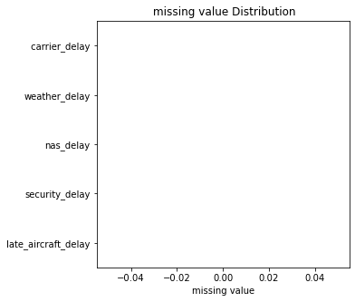

```python
plt.figure(figsize = [5,5])
na_counts = df_cause_only.isna().sum()
sns.barplot(na_counts, na_counts.index.values, color = base_color);
lables_name('missing value')
```

### Observation

#### NO missing values so we can take the next step.

```python
# Let us check the coorelation between the variables
df_cause.corr()
```

|  | year | month | arr_delay | carrier_delay | weather_delay | nas_delay | security_delay | late_aircraft_delay |
| --- | --- | --- | --- | --- | --- | --- | --- | --- |
| year | 1.000000 | -0.116346 | -0.094769 | -0.085580 | -0.048972 | -0.079273 | -0.035848 | -0.102829 |
| month | -0.116346 | 1.000000 | -0.004699 | -0.005047 | -0.017559 | -0.003660 | 0.017887 | -0.002384 |
| arr_delay | -0.094769 | -0.004699 | 1.000000 | 0.944814 | 0.786233 | 0.891744 | 0.356055 | 0.965524 |
| carrier_delay | -0.085580 | -0.005047 | 0.944814 | 1.000000 | 0.750904 | 0.740426 | 0.374212 | 0.912246 |
| weather_delay | -0.048972 | -0.017559 | 0.786233 | 0.750904 | 1.000000 | 0.650590 | 0.253757 | 0.731155 |
| nas_delay | -0.079273 | -0.003660 | 0.891744 | 0.740426 | 0.650590 | 1.000000 | 0.256082 | 0.781967 |
| security_delay | -0.035848 | 0.017887 | 0.356055 | 0.374212 | 0.253757 | 0.256082 | 1.000000 | 0.362361 |
| late_aircraft_delay | -0.102829 | -0.002384 | 0.965524 | 0.912246 | 0.731155 | 0.781967 | 0.362361 | 1.000000 |

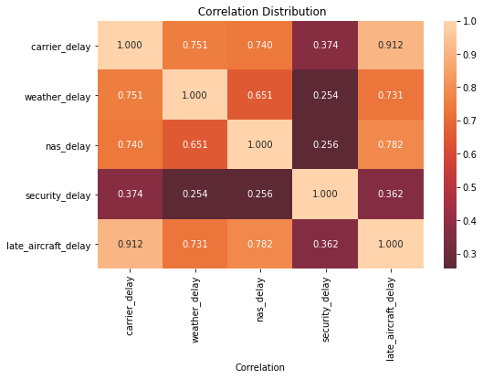

```python
plt.figure(figsize = [8, 5])
sns.heatmap(df_cause_only.corr(), annot = True, fmt = '.3f', center = 0)
lables_name('Correlation')
plt.show()
```

### Observation:

> 1. From the above figure we can make sure that there are no missing values
> 2. We can notice that the highest correlation exist between the follwing vaiables in descinding order ['late_aircraft_delay', ' carrier_delay','nas_delay','weather_delay', 'security_delay']

### Let us visulainzing our observations above and test it one by one

### 1. What is the most variable affecting on trip delay?

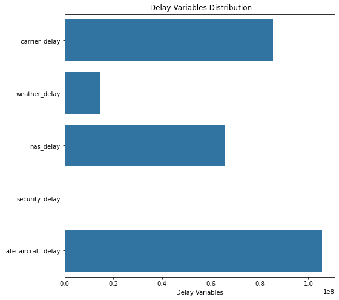

```python
plt.figure(figsize = [8,8])
delay=df_cause_only.sum()
sns.barplot(delay, delay.index.values, color = base_color);
lables_name('Delay Variables');
```

## Observation

### So the most variable cause delay is late_aircraft_delay

### 2. What about the most carrier in delay occurance?

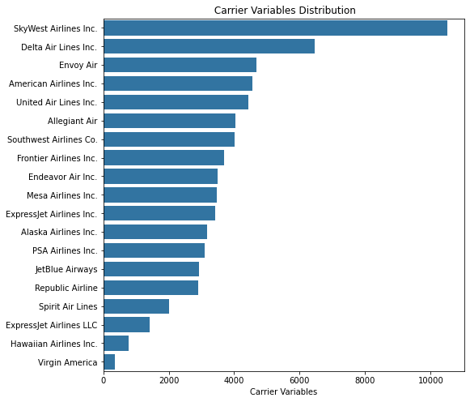

```python
plt.figure(figsize = [8,8])
carrier=df_cause['carrier_name'].value_counts()
sns.barplot(carrier, carrier.index.values, color = base_color);
lables_name('Carrier Variables');
```

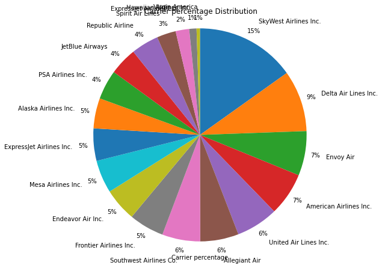

```python
plt.figure(figsize = [7,14])
counts = df_cause['carrier_name'].value_counts()
plt.pie(counts, labels = counts.index, autopct='%1.0f%%', pctdistance=1.1, labeldistance=1.2, startangle = 90, counterclock = False);

plt.axis('square')
lables_name('Carrier percentage')
```

## Observations:

#### With a percentage 15%

### 3. What about Destinations which one has the main share?

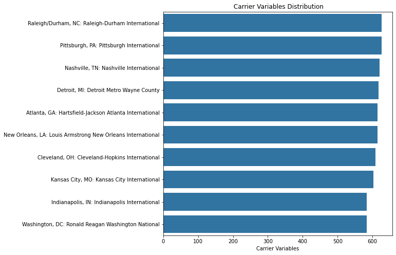

```python
plt.figure(figsize = [8,8])
destination=df_cause['airport_name'].value_counts()[:10]
sns.barplot(destination, destination.index.values, color = base_color);
lables_name('Carrier Variables');
```

## Observations:

### Actually I can't say that there is a certain airport cause delay they are almost the same

# Bivariate Exploration

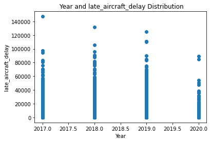

```python
plt.scatter(data = df_cause , x= 'year' , y = 'late_aircraft_delay');
lables_name('Year' , 'late_aircraft_delay')
```

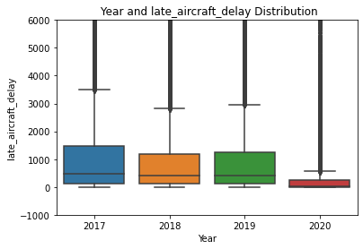

```python
ax= sns.boxplot(data = df_cause , x= 'year' , y = 'late_aircraft_delay');
ax.set(ylim=(-1000, 6000))
lables_name('Year' , 'late_aircraft_delay')
```

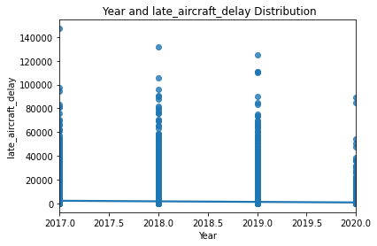

```python
sns.regplot(data = df_cause , x= 'year' , y = 'late_aircraft_delay');
lables_name('Year' , 'late_aircraft_delay')
```

# Observations

### From the above two graphs we can sse that the dealy causes is declining it's tendes to minimum in 2020

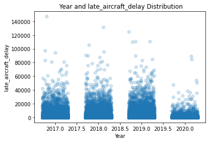

```python
sns.regplot(data = df_cause , x= 'year' , y = 'late_aircraft_delay', fit_reg = False ,x_jitter = 0.3 , scatter_kws = {'alpha' : 1/5});
lables_name('Year' , 'late_aircraft_delay')
```

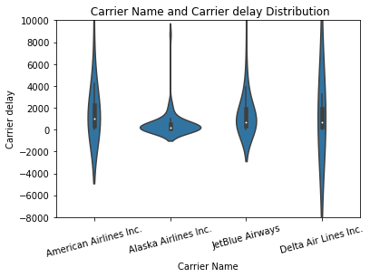

```python
sns.violinplot(data = df_cause[:300], x = 'carrier_name', y = ' carrier_delay',color = base_color);
plt.xticks(rotation = 15);
plt.ylim(-8000,10000);
lables_name('Carrier Name' , 'Carrier delay')
```

# Observation

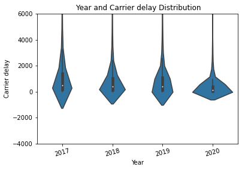

```python
sns.violinplot(data = df_cause, x = 'year', y = ' carrier_delay',color = base_color);
plt.xticks(rotation = 15);
plt.ylim(-4000,6000);
lables_name('Year' , 'Carrier delay')
```

# Observation

### The Highest median of carrier delay comes 2017

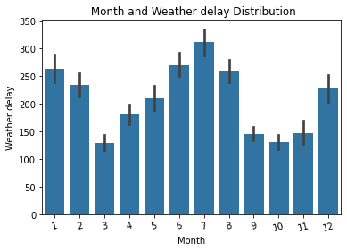

```python
sns.barplot(data = df_cause, x = ' month', y = 'weather_delay',color = base_color);
plt.xticks(rotation = 15);
lables_name('Month' , 'Weather delay')
```

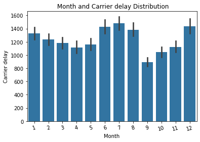

```python
sns.barplot(data = df_cause, x = ' month', y = ' carrier_delay',color = base_color);
plt.xticks(rotation = 15);
lables_name('Month' , 'Carrier delay')
```

## Observations:

#### The worest time to travel is from June to August.

#### The Best time to travel is from September to November.

```python
df_nas= df_cause[[ ' carrier_delay' ,'nas_delay','late_aircraft_delay' ]]
df_nas.corr()
```

|  | carrier_delay | nas_delay | late_aircraft_delay |
| --- | --- | --- | --- |
| carrier_delay | 1.000000 | 0.740426 | 0.912246 |
| nas_delay | 0.740426 | 1.000000 | 0.781967 |
| late_aircraft_delay | 0.912246 | 0.781967 | 1.000000 |

```python
ct_nas= df_cause.groupby([ 'carrier_name' ,'nas_delay' ]).size()
ct_nas
```

```
carrier_name          nas_delay
Alaska Airlines Inc.  0.0          344
                      1.0           11
                      2.0           15
                      3.0           17
                      4.0           10
                                  ...
Virgin America        28420.0        1
                      28682.0        1
                      29951.0        1
                      30567.0        1
                      43000.0        1
Length: 20783, dtype: int64
```

```python
ct_nas = ct_nas.reset_index(name= 'count')
ct_nas
```

|  | carrier_name | nas_delay | count |
| --- | --- | --- | --- |
| 0 | Alaska Airlines Inc. | 0.0 | 344 |
| 1 | Alaska Airlines Inc. | 1.0 | 11 |
| 2 | Alaska Airlines Inc. | 2.0 | 15 |
| 3 | Alaska Airlines Inc. | 3.0 | 17 |
| 4 | Alaska Airlines Inc. | 4.0 | 10 |
| ... | ... | ... | ... |
| 20778 | Virgin America | 28420.0 | 1 |
| 20779 | Virgin America | 28682.0 | 1 |
| 20780 | Virgin America | 29951.0 | 1 |
| 20781 | Virgin America | 30567.0 | 1 |
| 20782 | Virgin America | 43000.0 | 1 |

20783 rows × 3 columns

```python
ct_nas = ct_nas.pivot(index = 'nas_delay' , columns = 'carrier_name' , values = 'count')
ct_nas
```

| carrier_name nas_delay | Alaska Airlines Inc. | Allegiant Air | American Airlines Inc. | Delta Air Lines Inc. | Endeavor Air Inc. | Envoy Air | ExpressJet Airlines Inc. | ExpressJet Airlines LLC | Frontier Airlines Inc. | Hawaiian Airlines Inc. | JetBlue Airways | Mesa Airlines Inc. | PSA Airlines Inc. | Republic Airline | SkyWest Airlines Inc. | Southwest Airlines Co. | Spirit Air Lines | United Air Lines Inc. | Virgin America |
| --- | --- | --- | --- | --- | --- | --- | --- | --- | --- | --- | --- | --- | --- | --- | --- | --- | --- | --- | --- |
| 0.0 | 344.0 | 873.0 | 196.0 | 680.0 | 557.0 | 450.0 | 377.0 | 278.0 | 535.0 | 496.0 | 183.0 | 693.0 | 207.0 | 461.0 | 1709.0 | 120.0 | 158.0 | 452.0 | 12.0 |
| 1.0 | 11.0 | 42.0 | 10.0 | 46.0 | 25.0 | 16.0 | 14.0 | 5.0 | 6.0 | 6.0 | 12.0 | 5.0 | 4.0 | 14.0 | 44.0 | 14.0 | 15.0 | 14.0 | 2.0 |
| 2.0 | 15.0 | 47.0 | 5.0 | 34.0 | 16.0 | 10.0 | 14.0 | 5.0 | 16.0 | 4.0 | 6.0 | 11.0 | 4.0 | 14.0 | 31.0 | 11.0 | 6.0 | 14.0 | NaN |
| 3.0 | 17.0 | 47.0 | 8.0 | 35.0 | 23.0 | 21.0 | 18.0 | 12.0 | 13.0 | 7.0 | 11.0 | 12.0 | 11.0 | 10.0 | 35.0 | 9.0 | 4.0 | 13.0 | 1.0 |
| 4.0 | 10.0 | 42.0 | 15.0 | 30.0 | 8.0 | 14.0 | 17.0 | 3.0 | 13.0 | 8.0 | 15.0 | 9.0 | 8.0 | 10.0 | 43.0 | 9.0 | 2.0 | 20.0 | NaN |
| ... | ... | ... | ... | ... | ... | ... | ... | ... | ... | ... | ... | ... | ... | ... | ... | ... | ... | ... | ... |
| 88311.0 | NaN | NaN | NaN | NaN | NaN | NaN | NaN | NaN | NaN | NaN | NaN | NaN | NaN | NaN | NaN | NaN | NaN | 1.0 | NaN |
| 94239.0 | NaN | NaN | NaN | NaN | NaN | NaN | NaN | NaN | NaN | NaN | NaN | NaN | NaN | NaN | NaN | NaN | NaN | 1.0 | NaN |
| 97283.0 | NaN | NaN | 1.0 | NaN | NaN | NaN | NaN | NaN | NaN | NaN | NaN | NaN | NaN | NaN | NaN | NaN | NaN | NaN | NaN |
| 107073.0 | NaN | NaN | NaN | 1.0 | NaN | NaN | NaN | NaN | NaN | NaN | NaN | NaN | NaN | NaN | NaN | NaN | NaN | NaN | NaN |
| 112018.0 | NaN | NaN | NaN | 1.0 | NaN | NaN | NaN | NaN | NaN | NaN | NaN | NaN | NaN | NaN | NaN | NaN | NaN | NaN | NaN |

6295 rows × 19 columns

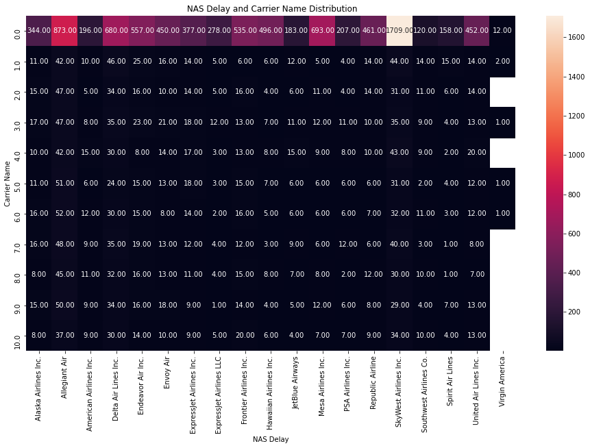

```python
plt.figure(figsize = [16,9])
sns.heatmap(ct_nas[:10] , annot =True , fmt = '.2f');
lables_name('NAS Delay' , 'Carrier Name' )
```

# Observation

## Multivariate Exploration

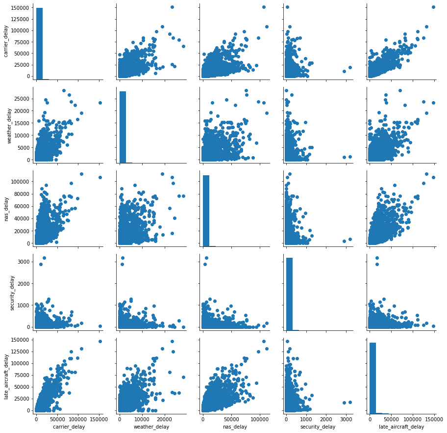

```python
ax = sns.PairGrid(data = df_cause , vars = df_cause_only);
ax = ax.map_offdiag(plt.scatter);
ax.map_diag(plt.hist);
```

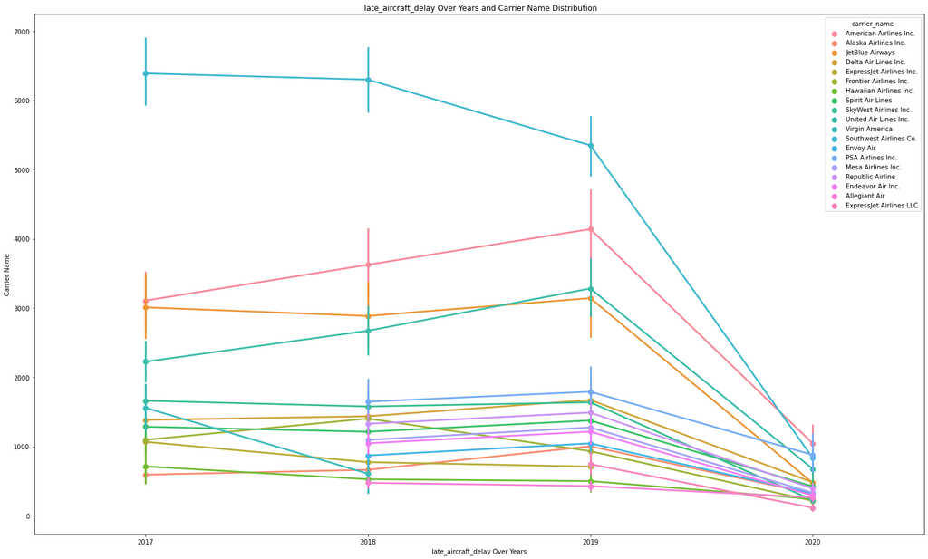

```python
plt.figure(figsize = [25,15])
sns.pointplot(data = df_cause, x = 'year',
            y = 'late_aircraft_delay', hue = "carrier_name");
lables_name('late_aircraft_delay Over Years' , 'Carrier Name' )
```

# Observation

### It Seems that the Airlines work hard to avoid and eleminate the delay causes as it is tending to the minimum in 2020